# 🐶 What We Learned from Thousands of Dog Tweets

You’ve probably seen tweets from WeRateDogs — the account that gives cute pups outrageous scores like "13/10 would pet again." But have you ever wondered what makes one dog tweet more popular than another?

We took a deep dive into over 2,000 tweets from the account and cleaned up a bunch of messy data to find out. Here's what we discovered:

## 1. "Pupper" Is the Internet’s Favorite Dog Stage

Dogs on the account are sometimes labeled with stages like “pupper,” “doggo,” “puppo,” and even “floofer.” Out of all these, “pupper” was by far the most common. It makes sense — it’s a cute word for a small dog, and people love cute things.

## 2. Retweets and Favorites Go Hand in Paw

When we looked at how many times a tweet was retweeted vs. how many times it was liked, we found a pretty clear pattern: if people like a tweet, they’re also likely to share it. The funnier or more adorable the dog, the more it spreads.

## 3. Golden Retrievers Are Basically Celebrities

Using the image prediction data, we saw that breeds like Golden Retrievers, Labradors, and Corgis were among the top-predicted dogs in the photos. These breeds are photogenic, friendly-looking, and already popular — a perfect recipe for going viral.

## Visualization

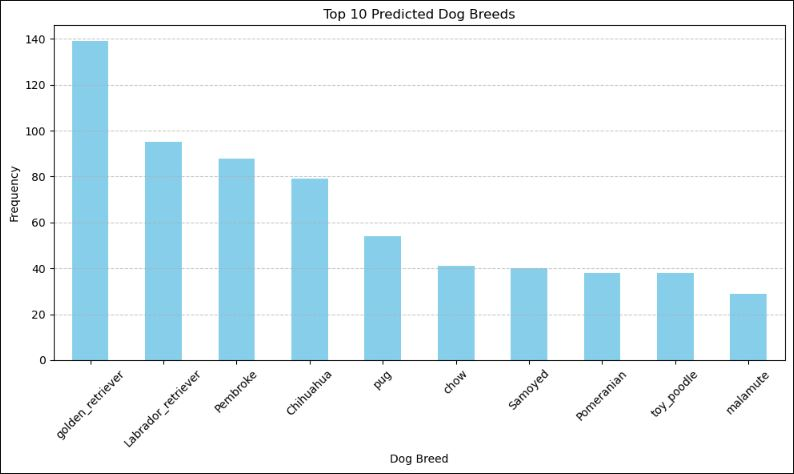

## 🐾 Final Thoughts

So what makes a dog tweet successful? A cute breed, a funny caption, and ideally — label them a "pupper." Simple. This project was a fun mix of data science and dog appreciation. We cleaned the data, crunched the numbers, and came away with some delightful insights.

Also: all dogs are good dogs. Science confirms it. 🐕✨